# 09_analysis

**Overall Insights**

This analysis suggests that spending behavior and CryoSleep status together influence transportation outcomes, with non-spenders in CryoSleep showing a strong tendency toward successful transportation.

```python
# Frequency tables for multiple columns at once
columns_to_analyze = ['Destination', 'HomePlanet']

# Loop through the columns and create a frequency table for each
for col in columns_to_analyze:
    print(f"\nFrequency table for {col}:\n")
    display(train_adj_df.stb.freq([col], cum_cols=False).round(2))
```

```
Frequency table for Destination:
```

|  | Destination | count | percent |
| --- | --- | --- | --- |
| 0 | TRAPPIST-1e | 6097 | 70.14 |
| 1 | 55 Cancri e | 1800 | 20.71 |
| 2 | PSO J318.5-22 | 796 | 9.16 |

```
Frequency table for HomePlanet:
```

|  | HomePlanet | count | percent |
| --- | --- | --- | --- |
| 0 | Earth | 4803 | 55.25 |
| 1 | Europa | 2131 | 24.51 |
| 2 | Mars | 1759 | 20.23 |

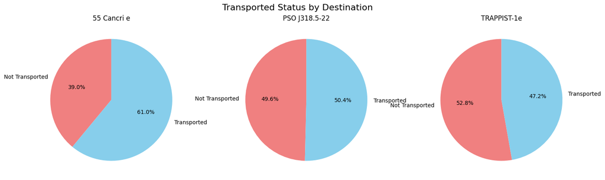

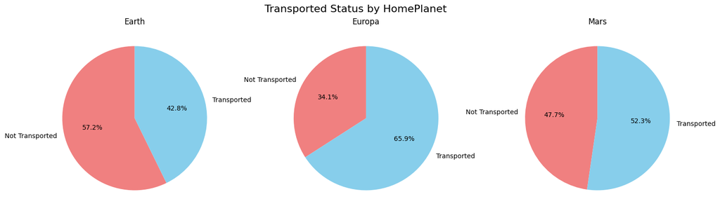

```python
# Group by Destination and Transported, calculate counts
destination_data = train_adj_df.groupby(
    ['Destination', 'Transported']).size().unstack().fillna(0)
destination_data.columns = ['Not Transported', 'Transported']

# Plot pie charts for Destination
fig, axes = plt.subplots(1, len(destination_data), figsize=(18, 5))
fig.suptitle('Transported Status by Destination', fontsize=16)

for i, (destination, counts) in enumerate(destination_data.iterrows()):
    axes[i].pie(counts, labels=['Not Transported', 'Transported'],
                autopct='%1.1f%%',
                startangle=90,
                colors=['lightcoral', 'skyblue'])
    axes[i].set_title(destination)

plt.show()

# Group by HomePlanet and Transported, calculate counts
homeplanet_data = train_adj_df.groupby(
    ['HomePlanet', 'Transported']).size().unstack().fillna(0)
homeplanet_data.columns = ['Not Transported', 'Transported']

# Plot pie charts for HomePlanet
fig, axes = plt.subplots(1, len(homeplanet_data), figsize=(18, 5))
fig.suptitle('Transported Status by HomePlanet', fontsize=16)

for i, (homeplanet, counts) in enumerate(homeplanet_data.iterrows()):
    axes[i].pie(counts, labels=['Not Transported', 'Transported'],
                autopct='%1.1f%%',
                startangle=90,
                colors=['lightcoral', 'skyblue'])
    axes[i].set_title(homeplanet)

plt.show()
```

1. **Conclusion: Transported Status by Destination**

   The destination appears to have an influence on the transportation outcome. Specifically:
- **55 Cancri e** is associated with a higher likelihood of transportation.
- **PSO J318.5-22** is neutral, showing nearly equal proportions.
- **TRAPPIST-1e** shows a slight tendency toward unsuccessful transportation outcomes.
2. **Conclusion: Transported Status by HomePlanet**

   The likelihood of transportation success appears to vary significantly by HomePlanet:
- **Europa** shows a strong positive association with successful transportation.
- **Earth** passengers are more likely to not be transported.
- **Mars** passengers are nearly evenly split but lean slightly toward successful transportation.